# Polishing with nthits and ntedit

Mar Llaberia-Robledillo

2023-05-15

## Filtering the FASTQ files for polishing

The first attempts to run ntEdits [@Warren2019] end up with a `std::bad_alloc` error, which may be due to insufficient memory. The assembly is about 453 million base pairs (<0.5 Gb), which is much less than the 20 Gb-genomes reported to be polished with ntHits in less than 30 minutes with 90 Gb of RAM [@Warren2019] (we have 250 Gb). The main difference between the examples reported in the original article and our attempt may be the size of the bloom filter (BF). While the authors used 17$\times$ sequence data for the bloom filter, we have probably more than double that (~35$\times$, in two FASTQ files).

Too much data in the FASTQ files could be the problem. Below, I use `vsearch` to get statistics of the expected number of errors per read in the first FASTQ file, then I filter the file to reduce the size and remove errors before running the `ntcard` and `nthits` programs.

```bash
FASTQ1=../../data/Shotgun_Illumina/IBC_2_Ex71_6_1.fastq.gz
FASTQ2=../../data/Shotgun_Illumina/IBC_2_Ex71_6_2.fastq.gz

if [ ! -e eestats1.txt ]; then
   vsearch --fastq_eestats2 $FASTQ1 \
           --output eestats1.txt \
           --ee_cutoffs 0.5,0.75,0.85,0.95,1
fi

if [ ! -e eestats2.txt ]; then
   vsearch --fastq_eestats2 $FASTQ2 \
           --output eestats2.txt \
           --ee_cutoffs 0.5,0.75,0.85,0.95,1
fi

if [ ! -e eestats_summary.txt ]; then
   gawk 'BEGIN{
      START = 0
      print "Length\tMaxEE0.50\tMaxEE0.75\tMaxEE0.85\tMaxEE0.95\tMaxEE1.00\tFile"
   }(START == 1){
      gsub(/[\(\)]/, "", $0)
      print $1 "\t" $2 "\t" $4 "\t" $6 "\t" $8 "\t" $10 "\tFASTQ1"
   }(/----/){START = 1}' eestats1.txt > eestats_summary.txt
   gawk 'BEGIN{
      START = 0
   }(START == 1){
      gsub(/[\(\)]/, "", $0)
      print $1 "\t" $2 "\t" $4 "\t" $6 "\t" $8 "\t" $10 "\tFASTQ2"
   }(/----/){START = 1}' eestats2.txt >> eestats_summary.txt
fi
```

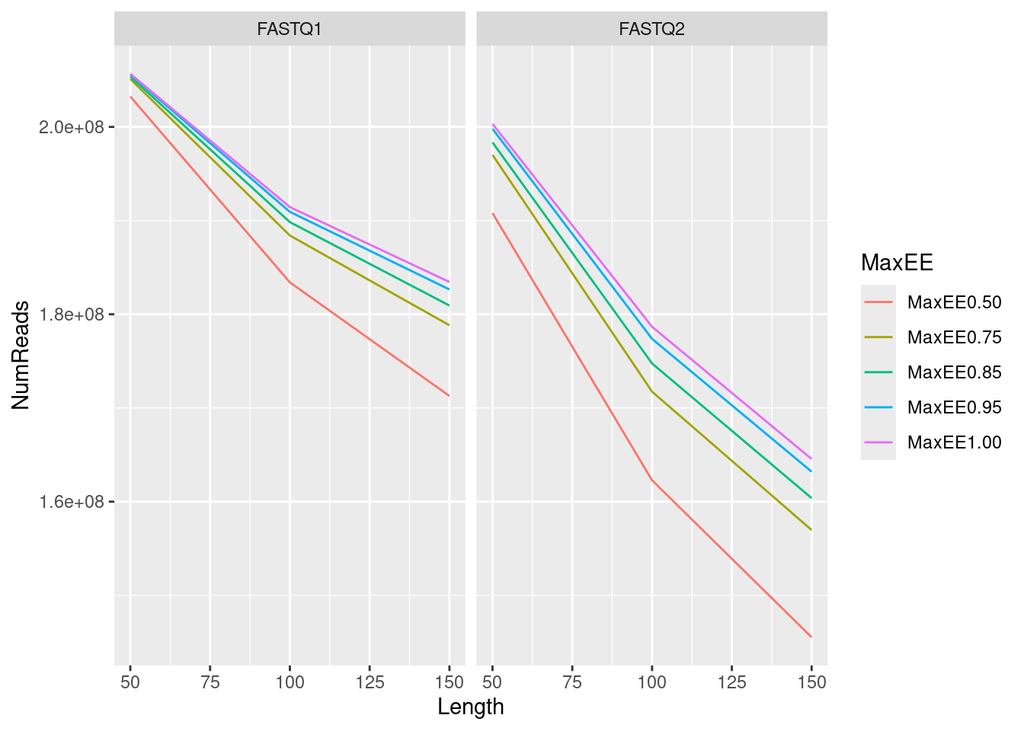

```r
library(ggplot2)
library(tidyr)
eestats <- read.table('eestats_summary.txt', header = TRUE)
eestats_L <- pivot_longer(eestats, 2:6, names_to = 'MaxEE', values_to = 'NumReads')
ggplot(data = eestats_L, mapping = aes(x = Length, y = NumReads, color = MaxEE)) +
   geom_line() + facet_wrap(~File)
```

```bash
FASTQ1=../../data/Shotgun_Illumina/IBC_2_Ex71_6_1.fastq.gz
FASTQ2=../../data/Shotgun_Illumina/IBC_2_Ex71_6_2.fastq.gz

if [ ! -e filtered1.fasta ]; then
   vsearch --fastq_filter $FASTQ1 \
           --fastaout filtered1.fasta \
           --fastq_maxee 0.5
fi

if [ ! -e filtered2.fasta ]; then
   vsearch --fastq_filter $FASTQ2 \
           --fastaout filtered2.fasta \
           --fastq_maxee 0.5
fi
```

```bash
for k in 31 47 61; do
   if [ ! -e filtered1_k$k.hist ]; then
      ntcard -k $k -t 16 -p filtered1 filtered1.fasta
   fi
done

for k in 31 47 61; do
   if [ ! -e filtered2_k$k.hist ]; then
      ntcard -k $k -t 16 -p filtered2 filtered2.fasta
   fi
done
```

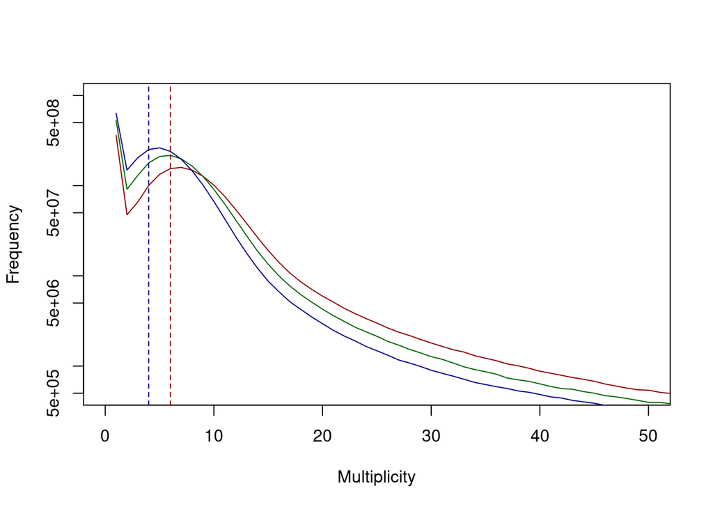

```r
k31 <- read.table('filtered1_k31.hist', skip = 2,
                  col.names = c('multiplicity', 'frequency'))
k47 <- read.table('filtered1_k47.hist', skip = 2,
                  col.names = c('multiplicity', 'frequency'))
k61 <- read.table('filtered1_k61.hist', skip = 2,
                  col.names = c('multiplicity', 'frequency'))
plot(k31$multiplicity, k31$frequency, type = 'l',
     xlim = c(0, 50), ylim = c(5.0e+05, 1.0e+09),
     log = 'y', xlab = 'Multiplicity',
     ylab = 'Frequency', col = 'darkred')
lines(k47$multiplicity, k47$frequency, col = 'darkgreen')
lines(k61$multiplicity, k61$frequency, col = 'darkblue')
abline(v = 6, col = 'darkred', lty = 2)
#abline(v = 5, col = 'darkgreen', lty = 2)
abline(v = 4, col = 'darkblue', lty = 2)
```

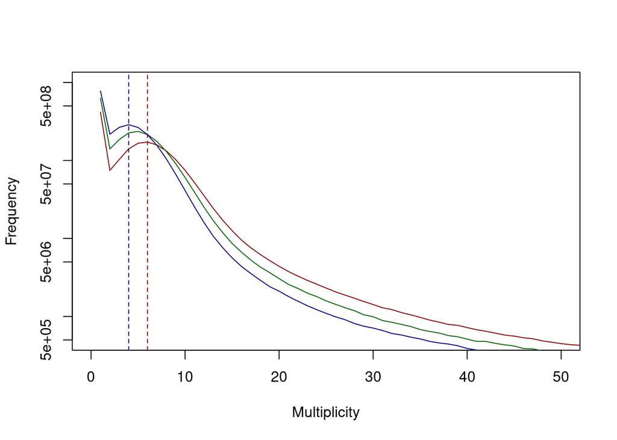

```r
k31 <- read.table('filtered2_k31.hist', skip = 2,
                  col.names = c('multiplicity', 'frequency'))
k47 <- read.table('filtered2_k47.hist', skip = 2,
                  col.names = c('multiplicity', 'frequency'))
k61 <- read.table('filtered2_k61.hist', skip = 2,
                  col.names = c('multiplicity', 'frequency'))
plot(k31$multiplicity, k31$frequency, type = 'l',
     xlim = c(0, 50), ylim = c(5.0e+05, 1.0e+09),
     log = 'y', xlab = 'Multiplicity',
     ylab = 'Frequency', col = 'darkred')
lines(k47$multiplicity, k47$frequency, col = 'darkgreen')
lines(k61$multiplicity, k61$frequency, col = 'darkblue')
abline(v = 6, col = 'darkred', lty = 2)
#abline(v = 5, col = 'darkgreen', lty = 2)
abline(v = 4, col = 'darkblue', lty = 2)
```

```bash
FASTA1=filtered1.fasta
FASTA2=filtered2.fasta

for k in 31 47 61; do
   if [ ! -e filtered_k$k.bf ]; then
      nthits --threads 16 \
             --kmer $k \
             --pref filtered \
             --outbloom \
             --solid \
             $FASTA1 $FASTA2 1> nthits_k$k.log 2> nthits_k$k.err
   fi
done
```

```bash
ASSEMBLY=../2023-05-12/flye/ONT_PB/assembly.fasta

for k in 31 47 61; do
   if [ ! -e ntedit_k${k}_edited.fa ]; then
      ntedit -t 32 \
             -f $ASSEMBLY \
             -r filtered_k$k.bf \
             -b ntedit_k$k \
             -v 1 1> ntedit_k$k.log 2> ntedit_k$k.err
   fi
   if [ ! -e changes_k$k.tsv ]; then
   # In the original file, not all lines have the same number of columns.
      cut -f 1,2,3,4,5 ntedit_k${k}_changes.tsv > changes_k$k.tsv
   fi
done
```

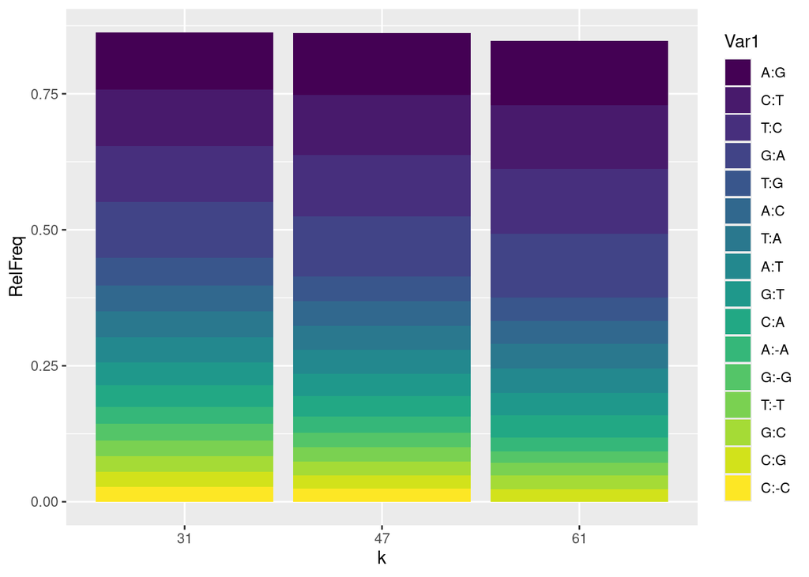

```r
changes_k31 <- read.table('changes_k31.tsv', header = TRUE, sep = '\t',
                          col.names = c('contig', 'position',
                                        'original', 'newbase', 'support'))
changes_k47 <- read.table('changes_k47.tsv', header = TRUE, sep = '\t',
                          col.names = c('contig', 'position',
                                        'original', 'newbase', 'support'))
changes_k61 <- read.table('changes_k61.tsv', header = TRUE, sep = '\t',
                         col.names = c('contig', 'position',
                                       'original', 'newbase', 'support'))
changes_k31$change <- paste(changes_k31$original,
                            changes_k31$newbase,
                            sep = ':')
changes_k47$change <- paste(changes_k47$original,
                            changes_k47$newbase,
                            sep = ':')
changes_k61$change <- paste(changes_k61$original,
                            changes_k61$newbase,
                            sep = ':')

profile31 <- as.data.frame(table(changes_k31$change))
profile31$k <- 31
profile31$RelFreq <- profile31$Freq / sum(profile31$Freq)
profile47 <- as.data.frame(table(changes_k47$change))
profile47$k <- 47
profile47$RelFreq <- profile47$Freq / sum(profile47$Freq)
profile61 <- as.data.frame(table(changes_k61$change))
profile61$k <- 61
profile61$RelFreq <- profile61$Freq / sum(profile61$Freq)
z <- rbind(profile31, profile47, profile61)
z2 <- pivot_wider(z, names_from = k, values_from = c('Freq', 'RelFreq'))
z2[is.na(z2)] <- 0
class(z2) <- 'data.frame'
z2$TotFreq <- z2$Freq_31 + z2$Freq_47 + z2$Freq_61
t <- order(z2$TotFreq, decreasing = TRUE)
class(z) <- 'data.frame'
z$Var1 <- ordered(z$Var1, levels = z2[t, 'Var1'])
z$k <- factor(as.character(z$k))
f <- z$RelFreq >= 0.02
ggplot(z[f,], aes(x = k, y = RelFreq, fill = Var1)) + geom_bar(stat = 'identity')
```

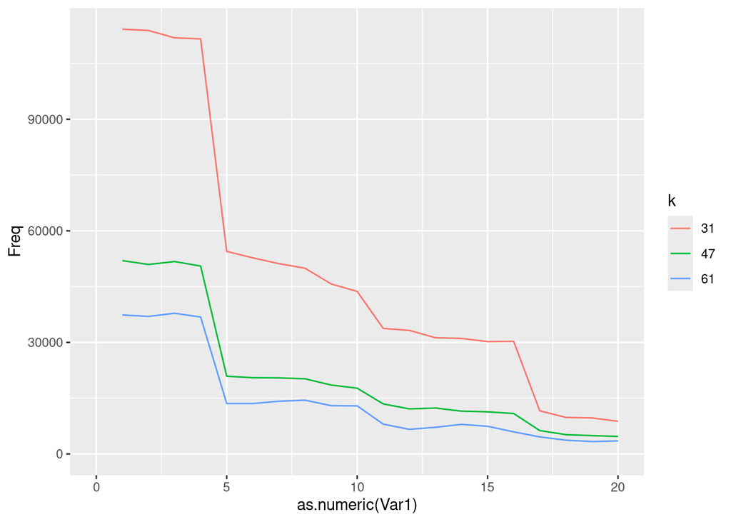

```r
ggplot(z, aes(x = as.numeric(Var1), y = Freq, color = k)) +
   geom_line() + xlim(0, 20)
```

The plots above represent different editions introduced by `ntedit` with different values of the $k$. Nothing important. It seems that using $k=31$ produces more editions, but not qualitatively different from those introduced when using higher values of $k$.

## Filtering and ordering of contigs

```r
library(Biostrings)
chosen <- readDNAStringSet('ntedit_k31_edited.fa')
AssInf <- read.table('../2023-05-12/flye/ONT_PB/assembly_info.txt',
                     col.names = c('ctg', 'len', 'cov', 'circ', 'rep',
                                   'mult', 'group', 'path'))
multi1 <- AssInf[AssInf$mult == 1, 'ctg']
multi1 <- intersect(multi1, names(chosen))
chosen <- chosen[multi1]
chosen <- chosen[order(width(chosen), decreasing = TRUE)]
writeXStringSet(chosen, 'assembly.fasta')
```

I write down in `assembly.fasta` a filtered and ordered version of the chosen assembly, with a total length of 206254914 nucleotides. Please, use `assembly.fasta` in this folder as a reference.